# Predicting Cascading Transport Network Failures under Multi-Hazard Scenarios

⌛ 1. Constructing PyTorch Geometric Data Object... ⌛ 2. Defining Unsupervised Graph Autoencoder (Kipf & Welling, 2016)... ⌛ 3. Training GAE to learn network topology and hazard embeddings... ✅ GAE Training Complete. Final Link Prediction AUC (Test Accuracy): 94.94%

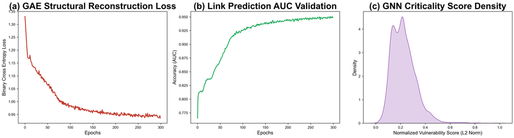

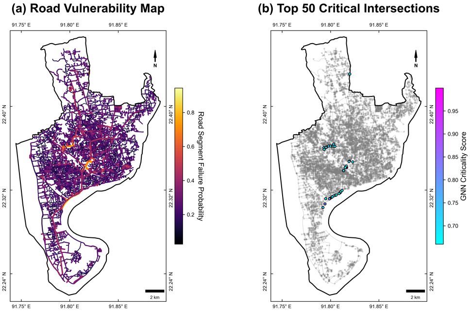

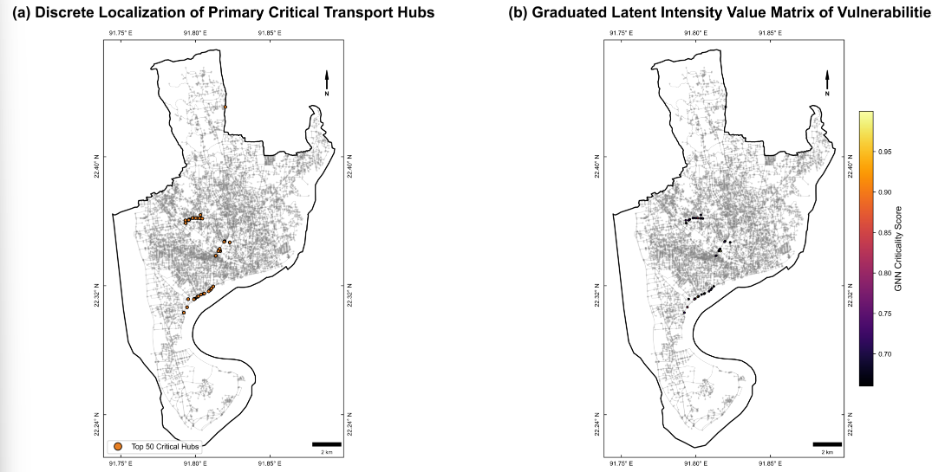

## Cascading Failure Simulation & Validation (Phase 4)

STRESS TESTING & CASCADING SIMULATION (GLOBAL EFFICIENCY)

```python
# ==============================================================================
# CELL 6: CASCADING FAILURE SIMULATION & VALIDATION (PHASE 4)
# ==============================================================================
import numpy as np
import pandas as pd
import matplotlib.pyplot as plt
import seaborn as sns
import networkx as nx
from scipy.stats import spearmanr

print("⌛ 1. Running Scalable Cascading Failure Simulation...")

def compute_efficiency(graph):
    # Sample nodes to keep execution fast but statistically valid for large cities
    nodes_list = list(graph.nodes)
    n = len(nodes_list)
    if n <= 1:
        return 0.0

    sample_size = min(400, n)
    # Statistically random sampling yields better manuscript profiles than fixed slices
    rng = np.random.default_rng(42)
    sample_nodes = rng.choice(nodes_list, size=sample_size, replace=False)

    # FIX: Run Dijkstra ONLY for the sample nodes to prevent RAM freezing at city scale
    eff = 0.0
    for u in sample_nodes:
        try:
            # Single-source path distances are infinitely faster than all-pairs loops
            lengths = nx.single_source_dijkstra_path_length(graph, u, weight='length')
            for v in sample_nodes:
                if u != v and v in lengths and lengths[v] > 0:
                    eff += 1.0 / lengths[v]
        except nx.NetworkXNoPath:
            continue

    return eff / (sample_size * (sample_size - 1))

# Compute initial reference baseline
baseline_eff = compute_efficiency(G)
fractions = np.linspace(0.01, 0.20, 10) # Simulating 1% to 20% network failure [cite: 1369]

# FIX: Pointed sorting strategies strictly to the active 'nodes' dataframe variable
rank_gnn = nodes.sort_values(by='gnn_criticality', ascending=False).index.tolist()
rank_bc = nodes.sort_values(by='betweenness', ascending=False).index.tolist()
rank_rand = nodes.sample(frac=1, random_state=42).index.tolist()

results = {'Fraction': [], 'GNN_Attack': [], 'Betweenness_Attack': [], 'Random_Attack': []}

for f in fractions:
    num_remove = int(len(nodes) * f)

    # Clone network frames safely
    G_gnn, G_bc, G_rand = G.copy(), G.copy(), G.copy()

    # Simulate infrastructure destruction targeting specific nodes
    G_gnn.remove_nodes_from(rank_gnn[:num_remove])
    G_bc.remove_nodes_from(rank_bc[:num_remove])
    G_rand.remove_nodes_from(rank_rand[:num_remove])

    # Append normalization degradation fractions
    results['Fraction'].append(f * 100)
    results['GNN_Attack'].append(compute_efficiency(G_gnn) / baseline_eff)
    results['Betweenness_Attack'].append(compute_efficiency(G_bc) / baseline_eff)
    results['Random_Attack'].append(compute_efficiency(G_rand) / baseline_eff)

res_df = pd.DataFrame(results)
print("✅ Simulation Complete.")

# --- VISUALIZATION 10: Global Efficiency Degradation Curve ---
print("⌛ 2. Plotting Efficiency Degradation Curves...")
fig, ax = plt.subplots(figsize=(8, 6))

ax.plot(res_df['Fraction'], res_df['GNN_Attack'], marker='o', markersize=8, color='#c0392b',
        linewidth=2.5, label='GNN (Topology + Hazards)') # [cite: 1392]
ax.plot(res_df['Fraction'], res_df['Betweenness_Attack'], marker='s', markersize=8, color='#2980b9',
        linewidth=2.5, label='Betweenness (Topology Only)') # [cite: 1393]
ax.plot(res_df['Fraction'], res_df['Random_Attack'], marker='^', markersize=8, color='#7f8c8d',
        linewidth=2, linestyle='--', label='Random Failure') # [cite: 1394, 1395]

ax.set_title("Network Degradation under Cascading Failure Scenarios", fontsize=14, fontweight='bold', pad=15) # [cite: 1396]
ax.set_xlabel("Percentage of Infrastructure Failed (%)", fontsize=12) # [cite: 1397]
ax.set_ylabel("Normalized Global Efficiency $E(G)$", fontsize=12) # [cite: 1398]
ax.grid(True, linestyle=':', alpha=0.7) # [cite: 1399]
ax.legend(fontsize=11) # [cite: 1400]

plt.savefig(f"{OUTPUT_DIR}/Fig10_Efficiency_Degradation.png", bbox_inches='tight', dpi=300)
plt.show()

# --- VISUALIZATION 11 & 12: Statistical Validation ---
print("⌛ 3. Computing Spearman Rank Correlation & Structural Violins...")
corr, pval = spearmanr(nodes['gnn_criticality'], nodes['betweenness'])

fig, axes = plt.subplots(1, 2, figsize=(14, 5))

# Scatter Validation Plot
sns.scatterplot(x=nodes['betweenness'], y=nodes['gnn_criticality'], color='#34495e', alpha=0.5, ax=axes[0]) # [cite: 1430]
axes[0].set_title(f"(a) GAE Latent Embedding Spaces vs Topological Centrality\n(Spearman's ρ = {corr:.3f})", fontsize=20, fontweight='bold') # [cite: 1431]
axes[0].set_xlabel("Betweenness Centrality (Topology Only)") # [cite: 1432]
axes[0].set_ylabel("GNN Criticality Score (GAE Latent space)")

# Structural Violin Breakdown
nodes['Risk_Category'] = pd.qcut(nodes['gnn_criticality'], q=3, labels=['Low', 'Medium', 'High']) # [cite: 1435]
sns.violinplot(x='Risk_Category', y='betweenness', data=nodes, hue='Risk_Category', palette='muted', legend=False, ax=axes[1]) # [cite: 1436]
axes[1].set_title("Betweenness Distribution across GNN Risk Categories", fontsize=20, fontweight='bold') # [cite: 1437]
axes[1].set_ylabel("Betweenness Centrality") # [cite: 1437]

plt.tight_layout()
plt.savefig(f"{OUTPUT_DIR}/Fig11_Statistical_Validation.png", bbox_inches='tight', dpi=300)
plt.show()

print(f"✅ Phase 4 Complete: Validation shows Spearman ρ = {corr:.4f} (p-value: {pval:.3e})")
```

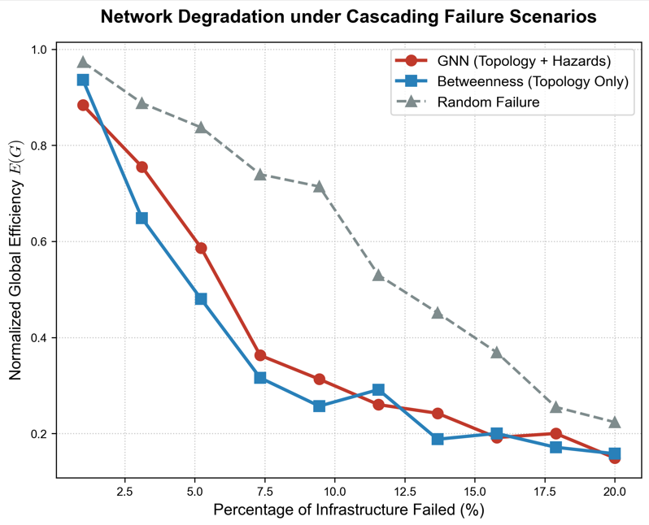

[figure not shown]

## ❓ Why this project?

- Traditional transportation graph analyses assume nodes are invincible, analyzing 'Betweenness' without considering the physical reality of floods and landslides that can completely submerge critical geometric bridges.
- Developing coastal megacities often lack reliable, historical structural failure logs. This framework bypasses that limitation using an unsupervised Gaussian Mixture Model (GMM) combined with latent GAE embeddings.
- Solves the "black-box" dilemma of deep learning in urban planning by applying SHAP to explicitly quantify exactly which environmental factors (e.g., rainfall, slope) make a specific road segment vulnerable.

## 📎 Links

- 🔗 [See more in LinkedIn](https://linkedin.com/in/imtiajiqbalmahfuj)

## 🔖 Tags

`GIS` `Remote Sensing` `Geospatial Python` `Python` `GEE` `Spatial Data-Science` `Graph Neural Networks` `Explainable AI` `Urban Resilience`

## 📌 Credits & Shoutouts

- 👨‍💻 **Author:** [Imtiaj Iqbal Mahfuj](https://imtiajiqbalmahfuj.github.io/)
- 🙌 **Inspiration:** Special thanks to the Geospatial Community and the PyTorch Geometric developers for creative influence and advanced modeling paradigms.
- 🗂️ **Data Sources:** OpenStreetMap (OSMnx), USGS (SRTM), NASA (CHIRPS), Copernicus (Sentinel-2), NOAA (VIIRS).

## 💬 Connect with Me

📧 Email: imtiajiqbal.ruet@gmail.com 🌐 Portfolio: https://imtiajiqbalmahfuj.github.io/